# TP6- Dellouve et Gazzo

## Exercice 2

```r
#Question 1

call<-function(sigma,K,r=0,S=1) # fonction call
{
    C=S*exp(r)*(1- pnorm(log(K/S)/sigma-r/sigma-sigma/2))-K*(1- pnorm(log(K/S)/sigma-r/sigma+sigma/2))
    return(C)
}

put<-function(sigma,K,r=0,S=1) # fonction put
{
  P=K*(pnorm(log(K/S)/sigma-r/sigma+sigma/2))-S*exp(r)*pnorm(log(K/S)/sigma-r/sigma-sigma/2)
  return(P)
}

call(1,1)-put(1,1) # vérification, ca doit valoir 0
```

```
## [1] -5.551115e-17
```

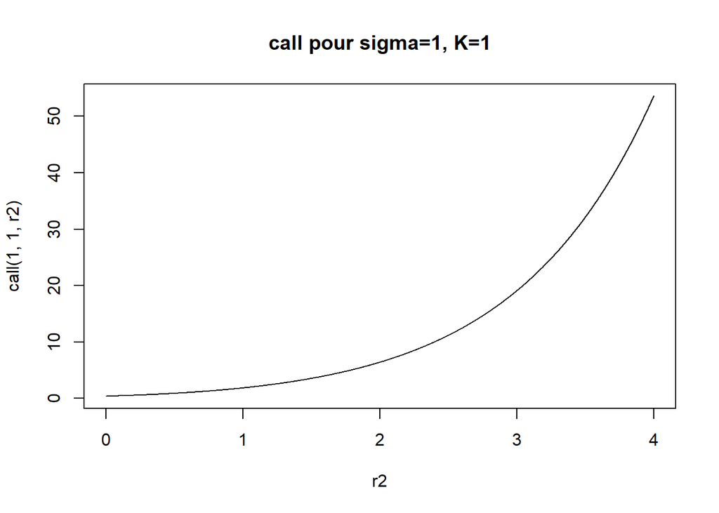

```r
r<-seq(0,1,0.0005) #taux d’intérêt instantanné
r2<-seq(0,4,0.0005) #taux d’intérêt instantanné

plot(r2,call(1,1,r2),type='l',main = "call pour sigma=1, K=1")
```

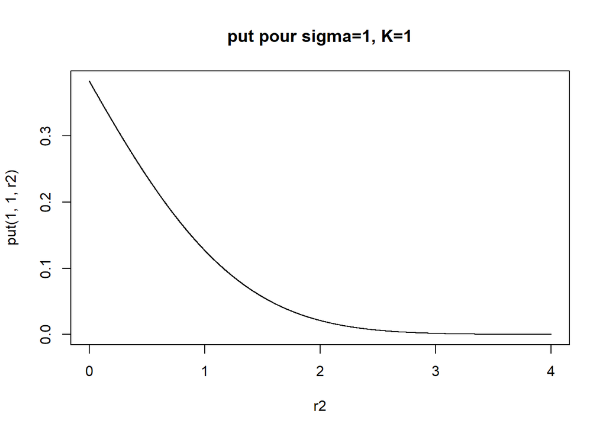

```r
plot(r2,put(1,1,r2),type='l',main = "put pour sigma=1, K=1")
```

En traçant les graphiques pour $K$ fixé et pour différentes valeurs de sigma, on observe que la fonction $\texttt{call}$ est croissante alors que la fonction $\texttt{put}$ est décroissante et converge vers $0$. On trace ensuite les graphiques pour comparer les résultats obtenus pour $K$ fixé et ensuite pour $\sigma$ fixé.

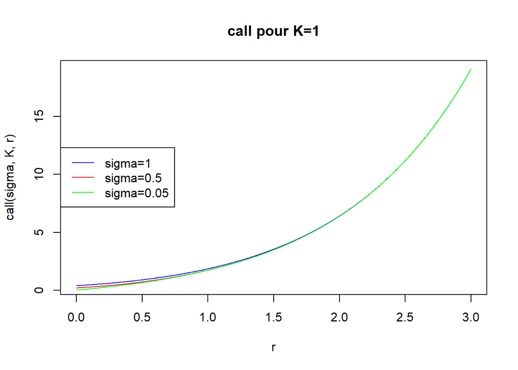

```r
r<-seq(0,3,0.0005) #taux d’intérêt instantanné

#cas K=1, pour différents sigma
K<-1
sigma<-1.0
plot(r,call(sigma,K,r),type='l',main = "call pour K=1",col='blue')
sigma<-0.5
lines(r,call(sigma,K,r),type='l',col='red')
sigma<-0.05
lines(r,call(sigma,K,r),type='l',col='green')
legend("left",c("sigma=1","sigma=0.5","sigma=0.05"),col=c('blue','red','green'),
       lwd=1,lty=1)
```

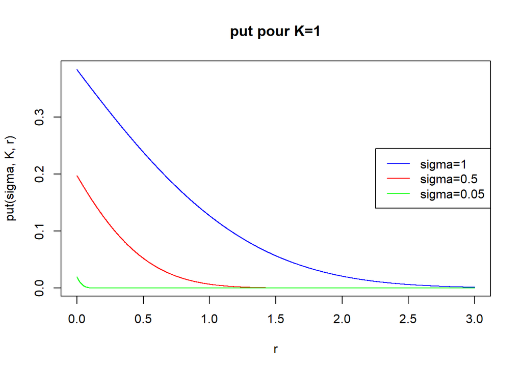

```r
sigma<-1.0
plot(r,put(sigma,K,r),type='l',main = "put pour K=1",col='blue')
sigma<-0.5
lines(r,put(sigma,K,r),type='l',col='red')
sigma<-0.05
lines(r,put(sigma,K,r),type='l',col='green')
legend("right",c("sigma=1","sigma=0.5","sigma=0.05"),col=c('blue','red','green'),
       lwd=1,lty=1)
```

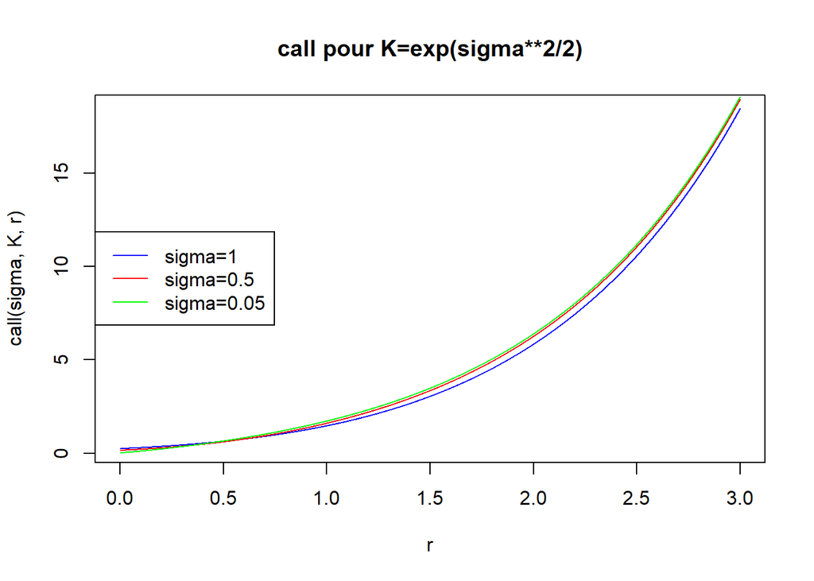

```r
#cas K=exp(sigma**2/2), pour différents sigma
sigma<-1.0
K<-exp(sigma**2/2)
plot(r,call(sigma,K,r),type='l',main = "call pour K=exp(sigma**2/2)",col='blue')
sigma<-0.5
K<-exp(sigma**2/2)
lines(r,call(sigma,K,r),type='l',col='red')
sigma<-0.05
K<-exp(sigma**2/2)
lines(r,call(sigma,K,r),type='l',col='green')
legend("left",c("sigma=1","sigma=0.5","sigma=0.05"),col=c('blue','red','green'),
       lwd=1,lty=1)
```

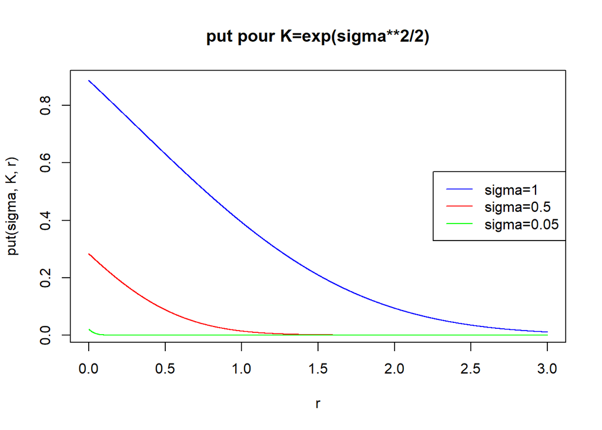

```r
sigma<-1.0
K<-exp(sigma**2/2)
plot(r,put(sigma,K,r),type='l',main = "put pour K=exp(sigma**2/2)",col='blue')
sigma<-0.5
K<-exp(sigma**2/2)
lines(r,put(sigma,K,r),type='l',col='red')
sigma<-0.05
K<-exp(sigma**2/2)
lines(r,put(sigma,K,r),type='l',col='green')
legend("right",c("sigma=1","sigma=0.5","sigma=0.05"),col=c('blue','red','green'),
       lwd=1,lty=1)
```

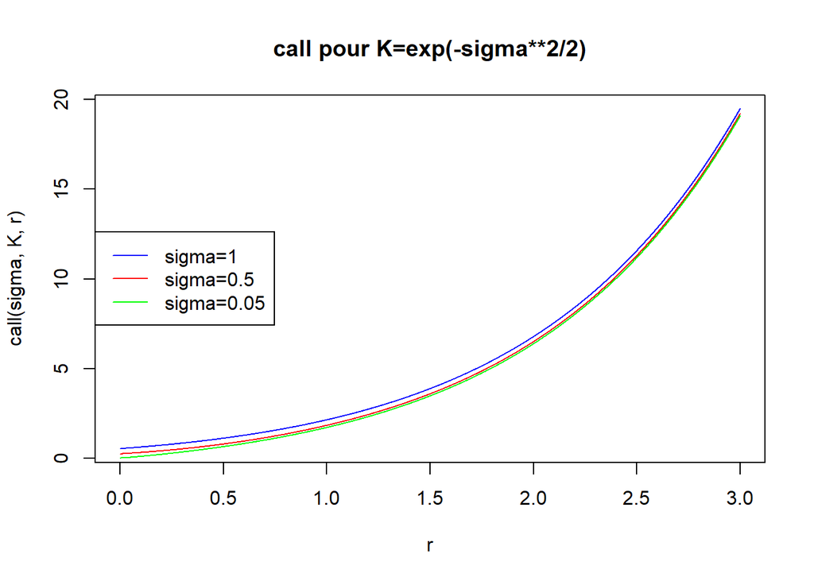

```r
#cas K=exp(-sigma**2/2), pour différents sigma
sigma<-1.0
K<-exp(-sigma**2/2)
plot(r,call(sigma,K,r),type='l',main = "call pour K=exp(-sigma**2/2)",col='blue')
sigma<-0.5
K<-exp(-sigma**2/2)
lines(r,call(sigma,K,r),type='l',col='red')
sigma<-0.05
K<-exp(-sigma**2/2)
lines(r,call(sigma,K,r),type='l',col='green')
legend("left",c("sigma=1","sigma=0.5","sigma=0.05"),col=c('blue','red','green'),
       lwd=1,lty=1)
```

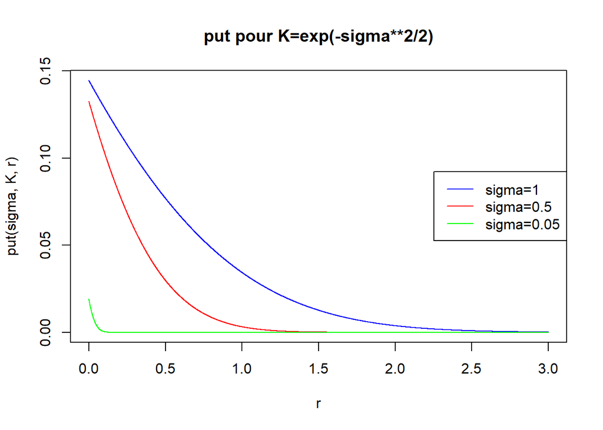

```r
sigma<-1.0
K<-exp(-sigma**2/2)
plot(r,put(sigma,K,r),type='l',main = "put pour K=exp(-sigma**2/2)",col='blue')
sigma<-0.5
K<-exp(-sigma**2/2)
lines(r,put(sigma,K,r),type='l',col='red')
sigma<-0.05
K<-exp(-sigma**2/2)
lines(r,put(sigma,K,r),type='l',col='green')
legend("right",c("sigma=1","sigma=0.5","sigma=0.05"),col=c('blue','red','green'),
       lwd=1,lty=1)
```

On voit que plus $\sigma$ est grand, plus la fonction $\texttt{call}$ commence avec une valeur élevée. La courbe croît plus fortement pour $\sigma$ petit. On voit que la valeur de $K$ influence le phénomène. Pour $K$ petit, les courbes se croisent plus tard comparé au cas $K$ grand.

Pour la fonction $\texttt{put}$, on observe que plus $\sigma$ est petit, plus la courbe converge rapidement vers $0$ et commence à une valeur faible en $x=0$. D’autre part, $K$ influence aussi le point de départ de la courbe à l’origine, au plus $K$ est grand, au plus la valeur à l’origine sera grande.

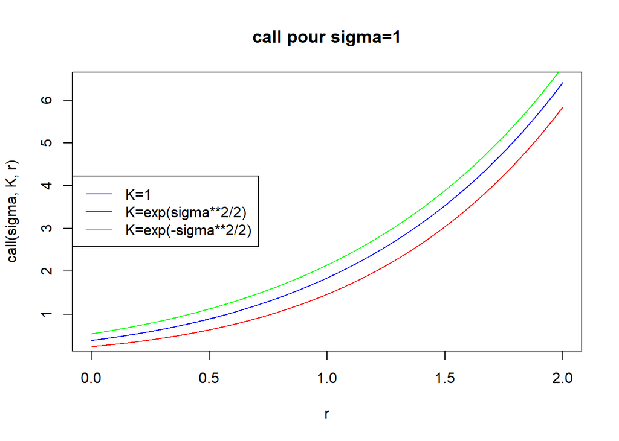

```r
r<-seq(0,2,0.0005) #taux d’intérêt instantanné

#cas sigma=1, pour différents sigma
sigma<-1.0
K<-1
plot(r,call(sigma,K,r),type='l',main = "call pour sigma=1",col='blue')
K<-exp(sigma**2/2)
lines(r,call(sigma,K,r),type='l',col='red')
K<-exp(-sigma**2/2)
lines(r,call(sigma,K,r),type='l',col='green')
legend("left",c("K=1","K=exp(sigma**2/2)","K=exp(-sigma**2/2)"),
       col=c('blue','red','green'),lwd=1,lty=1)
```

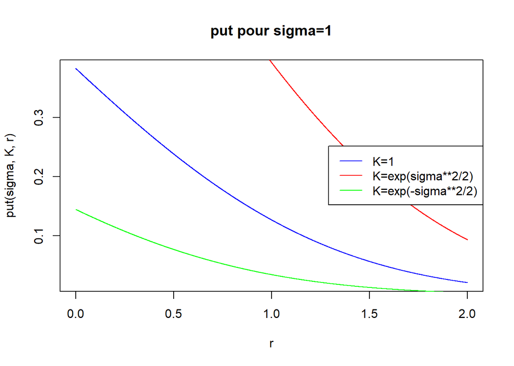

```r
K<-1
plot(r,put(sigma,K,r),type='l',main = "put pour sigma=1",col='blue')
K<-exp(sigma**2/2)
lines(r,put(sigma,K,r),type='l',col='red')
K<-exp(-sigma**2/2)
lines(r,put(sigma,K,r),type='l',col='green')
legend("right",c("K=1","K=exp(sigma**2/2)","K=exp(-sigma**2/2)"),
       col=c('blue','red','green'),lwd=1,lty=1)
```

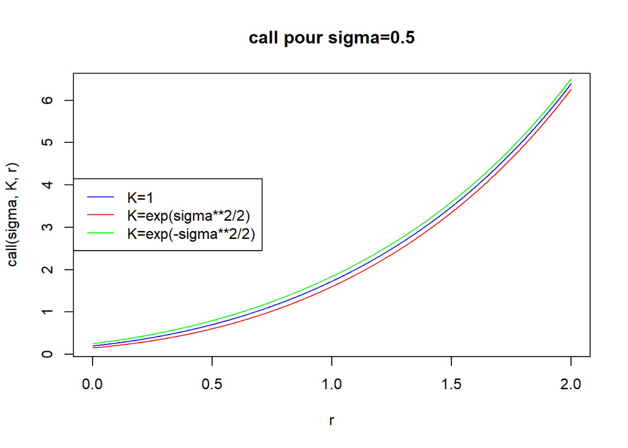

```r
#cas sigma=0.5, pour différents sigma
sigma<-0.5
K<-1
plot(r,call(sigma,K,r),type='l',main = "call pour sigma=0.5",col='blue')
K<-exp(sigma**2/2)
lines(r,call(sigma,K,r),type='l',col='red')
K<-exp(-sigma**2/2)
lines(r,call(sigma,K,r),type='l',col='green')
legend("left",c("K=1","K=exp(sigma**2/2)","K=exp(-sigma**2/2)"),
       col=c('blue','red','green'),lwd=1,lty=1)
```

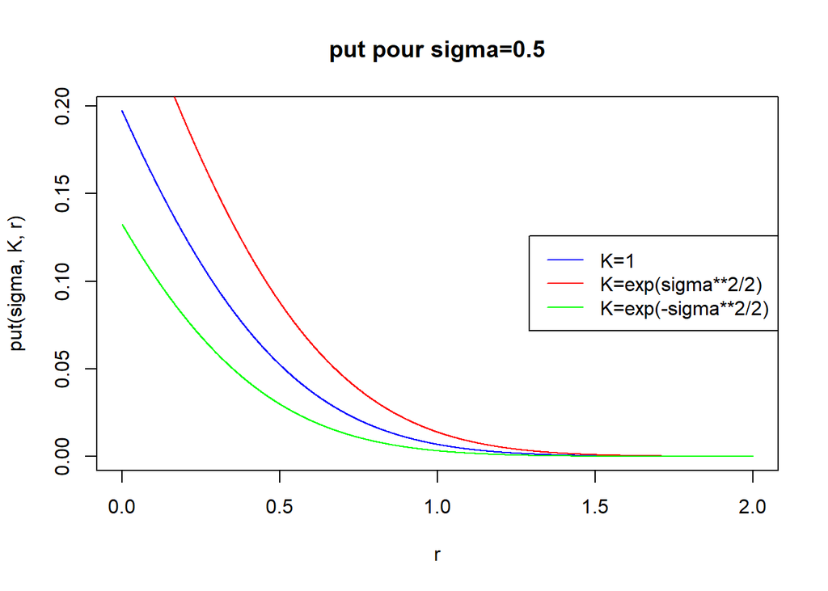

```r
K<-1
plot(r,put(sigma,K,r),type='l',main = "put pour sigma=0.5",col='blue')
K<-exp(sigma**2/2)
lines(r,put(sigma,K,r),type='l',col='red')
K<-exp(-sigma**2/2)
lines(r,put(sigma,K,r),type='l',col='green')
legend("right",c("K=1","K=exp(sigma**2/2)","K=exp(-sigma**2/2)"),
       col=c('blue','red','green'),lwd=1,lty=1)
```

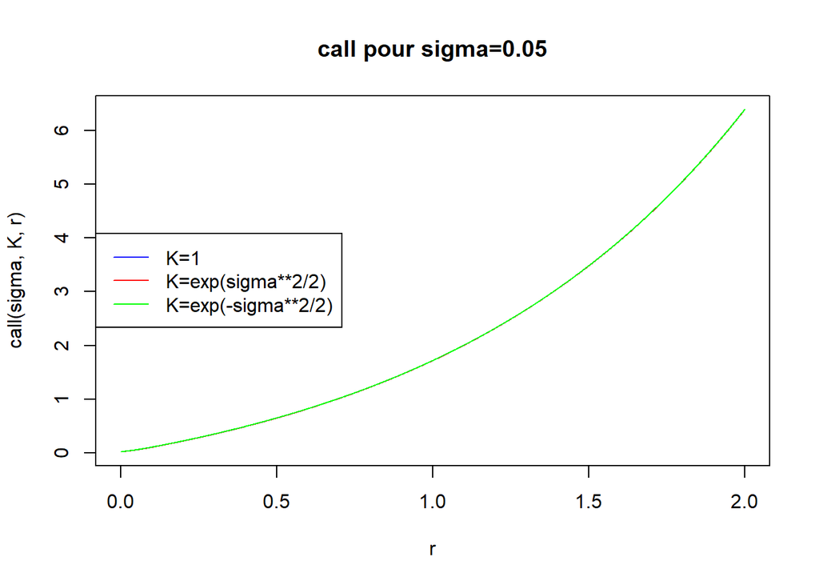

```r
#cas sigma=0.05, pour différents sigma
sigma<-0.05
K<-1
plot(r,call(sigma,K,r),type='l',main = "call pour sigma=0.05",col='blue')
K<-exp(sigma**2/2)
lines(r,call(sigma,K,r),type='l',col='red')
K<-exp(-sigma**2/2)
lines(r,call(sigma,K,r),type='l',col='green')
legend("left",c("K=1","K=exp(sigma**2/2)","K=exp(-sigma**2/2)"),
       col=c('blue','red','green'),lwd=1,lty=1)
```

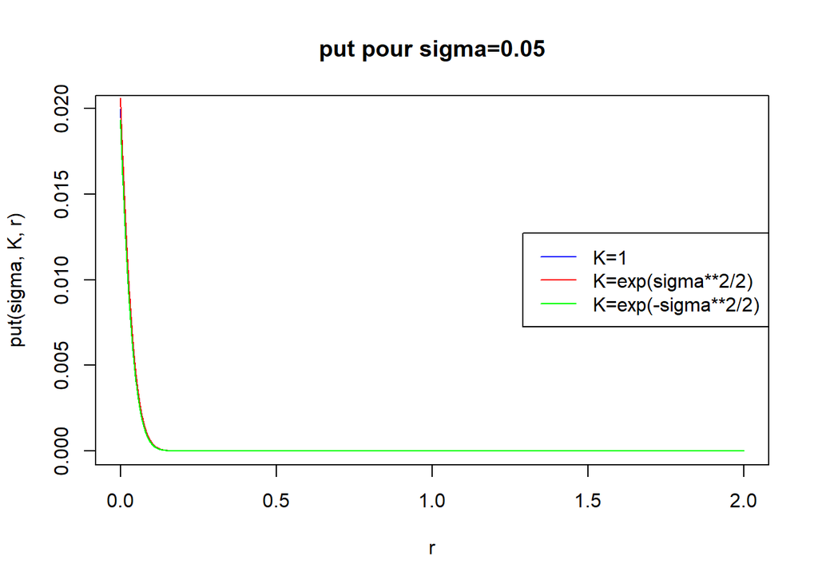

```r
K<-1
plot(r,put(sigma,K,r),type='l',main = "put pour sigma=0.05",col='blue')
K<-exp(sigma**2/2)
lines(r,put(sigma,K,r),type='l',col='red')
K<-exp(-sigma**2/2)
lines(r,put(sigma,K,r),type='l',col='green')
legend("right",c("K=1","K=exp(sigma**2/2)","K=exp(-sigma**2/2)"),
       col=c('blue','red','green'),lwd=1,lty=1)
```

On remarque ici que plus $\sigma$ est petit, plus les courbes se rapprochent.

## Exercice 3

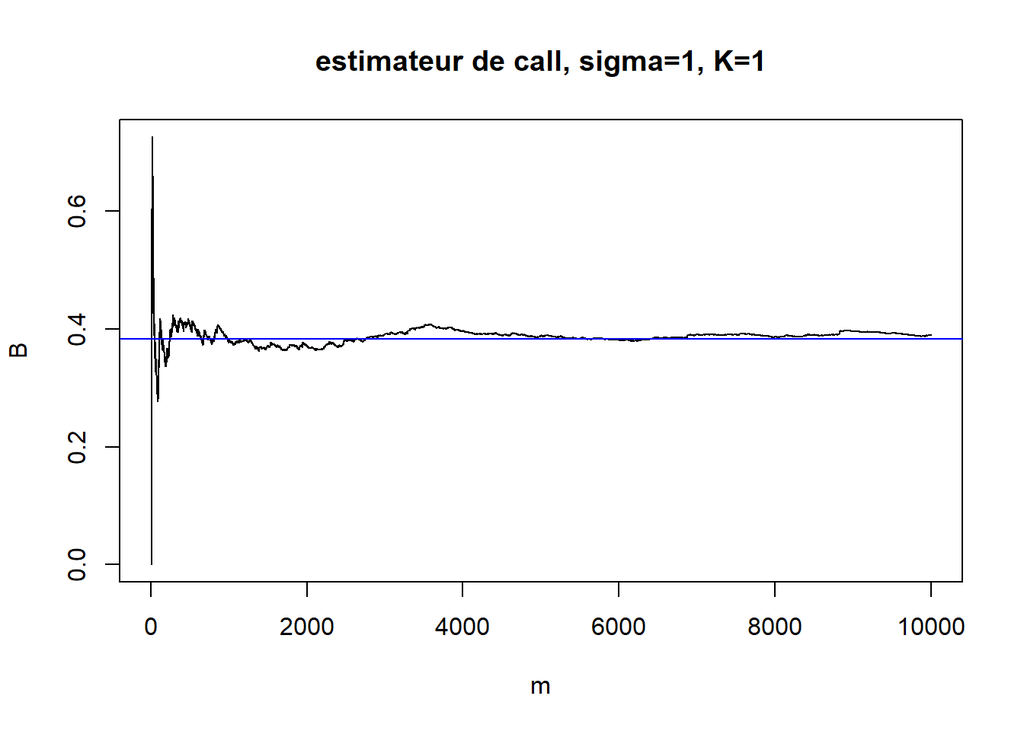

```r
rcallput<-function(n, sigma, K)
{
  X<-rnorm(n) #3 On simule n Xi suivant une loi normale centrée réduite
  Y<-exp(sigma*X-sigma**2/2)-K
  Z<-K-exp(sigma*X-sigma**2/2)
  M<-matrix(ncol=2,nrow=n) #matrice de stockage des couples
  M[,1]=Y*(Y>0); M[,2]=Z*(Z>0)
  return(M)
}

A<-rcallput(1000,1,1) # simulation pour n=1000 et K=sigma=1

m<-seq(1,10000,1) # entier de 1 a 10 000



#test1
A<-rcallput(10000,1,1) # n=10 000
B<-cumsum(A[,1])/m # Ym barre

plot(m,B,type='l',main="estimateur de call, sigma=1, K=1") #Ym en fonctio de m, on voit la convergence
call_niveau<-call(1,1)
abline(call_niveau,0,col='blue') # on converge bien vers call
```

```r
var(B) #variance de Ym
```

```
## [1] 0.0003869155
```

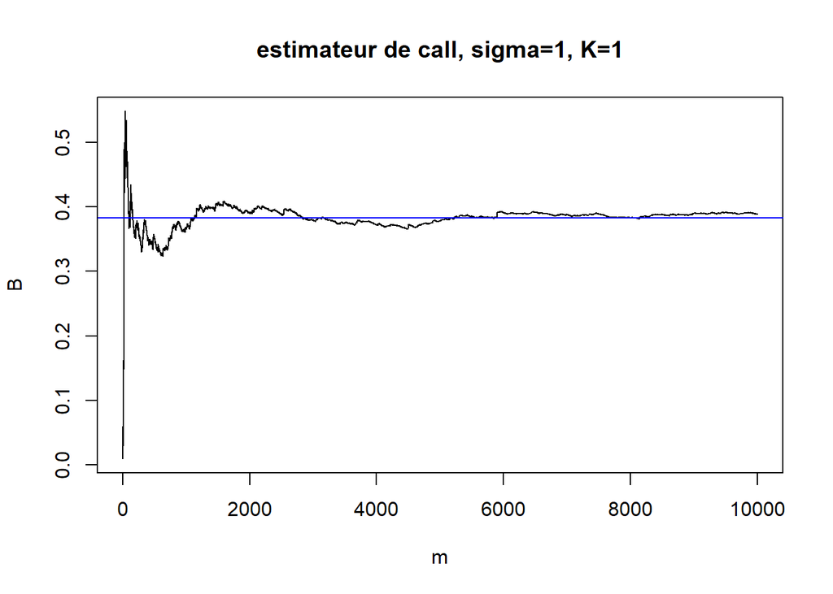

```r
#test2
A<-rcallput(10000,1,1) # n=10 000
B<-cumsum(A[,1])/m # Ym barre

plot(m,B,type='l',main="estimateur de call, sigma=1, K=1") #Ym en fonctio de m, on voit la convergence
call_niveau<-call(1,1)
abline(call_niveau,0,col='blue') # on converge bien vers call
```

```r
var(B) #variance de Ym
```

```
## [1] 0.000406919
```

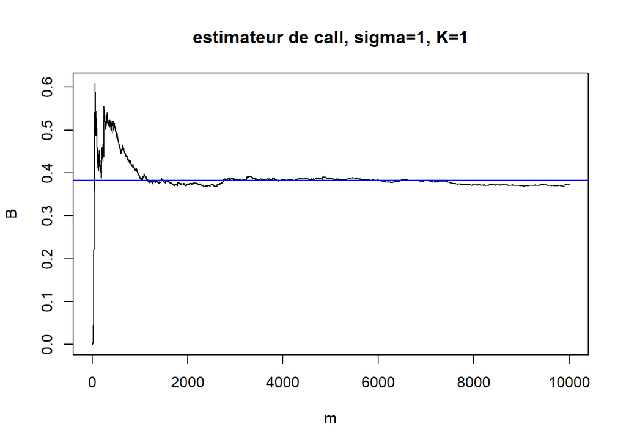

```r
#test3
A<-rcallput(10000,1,1) # n=10 000
B<-cumsum(A[,1])/m # Ym barre

plot(m,B,type='l',main="estimateur de call, sigma=1, K=1") #Ym en fonctio de m, on voit la convergence
call_niveau<-call(1,1)
abline(call_niveau,0,col='blue') # on converge bien vers call
```

```r
var(B) #variance de Ym
```

```
## [1] 0.001269413
```

On observe que les estimateurs convergent vers la valeur calculée par la fonction $\texttt{call}$.

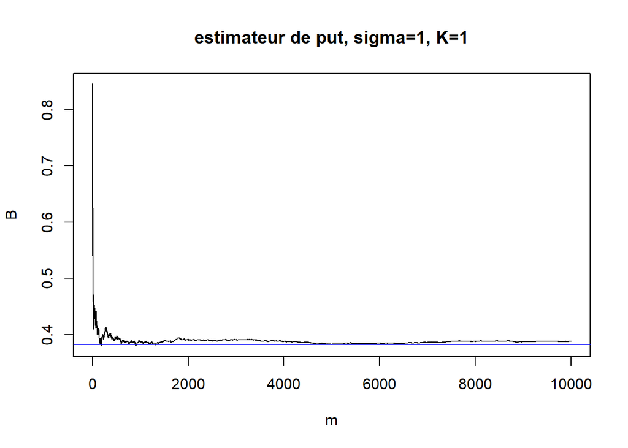

```r
#test1
A<-rcallput(10000,1,1) # n=10 000
B<-cumsum(A[,2])/m # Zm barre

plot(m,B,type='l',main="estimateur de put, sigma=1, K=1") #Zm en fonctio de m, on voit la convergence
put_niveau<-put(1,1)
abline(put_niveau,0,col='blue') # on converge bien vers put
```

```r
var(B) #variance de Zm
```

```
## [1] 9.131761e-05
```

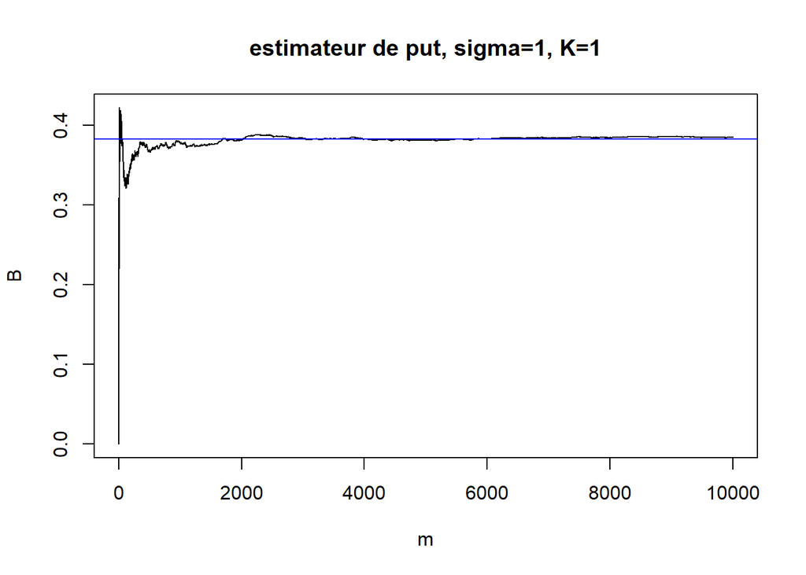

```r
#test2
A<-rcallput(10000,1,1) # n=10 000
B<-cumsum(A[,2])/m # Zm barre

plot(m,B,type='l',main="estimateur de put, sigma=1, K=1") #Zm en fonctio de m, on voit la convergence
put_niveau<-put(1,1)
abline(put_niveau,0,col='blue') # on converge bien vers put
```

```r
var(B) #variance de Zm
```

```
## [1] 9.695097e-05
```

On observe que les estimateurs convergent vers la valeur calculée par la fonction $\texttt{put}$.

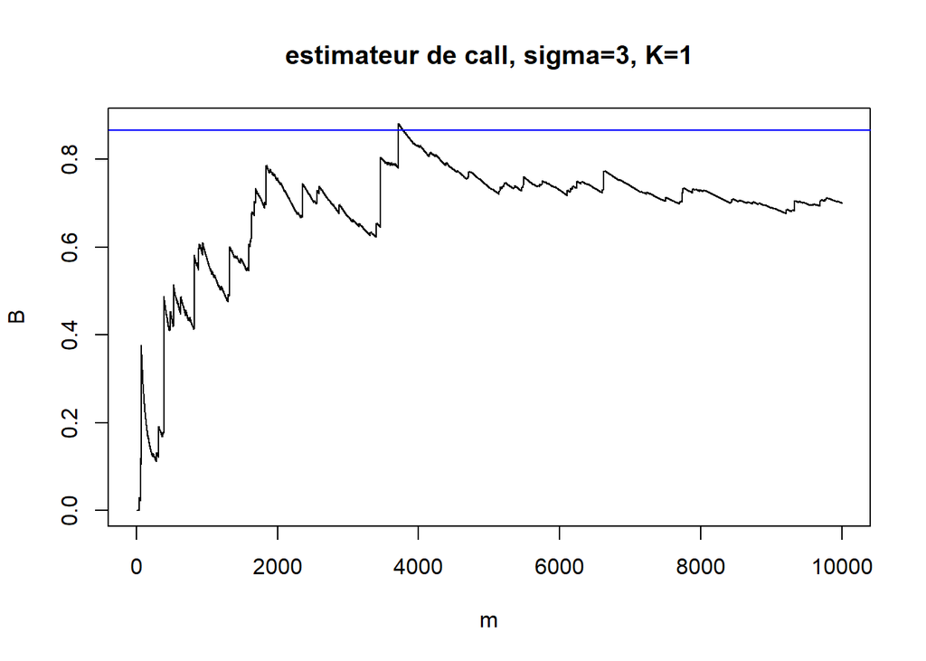

```r
#test1
A<-rcallput(10000,3,1)
B<-cumsum(A[,1])/m # Ym barre
C<-cumsum(A[,2])/m # Zm barre
call_niveau<-call(3,1)
put_niveau<-put(3,1)

plot(m,B,type='l',main="estimateur de call, sigma=3, K=1")
abline(call_niveau,0,col='blue') # on converge bien vers call
```

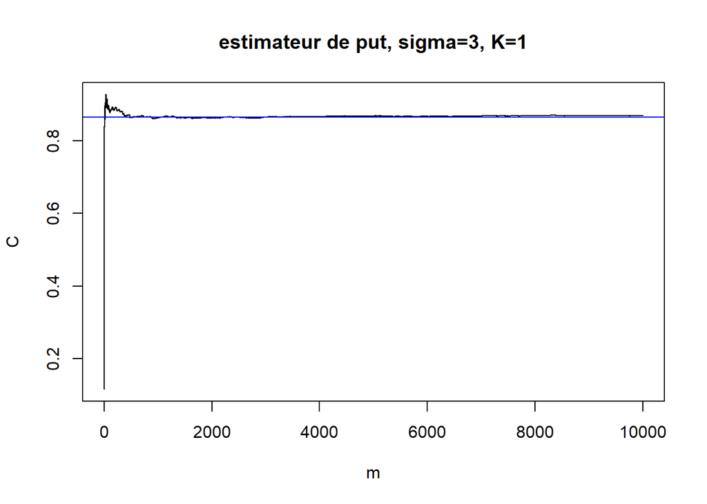

```r
plot(m,C,type='l',main="estimateur de put, sigma=3, K=1")
abline(put_niveau,0,col='blue') # on converge bien vers call
```

```r
var(B) #variance de Ym
```

```
## [1] 0.01855574
```

```r
var(C) #variance de Zm
```

```
## [1] 9.325699e-05
```

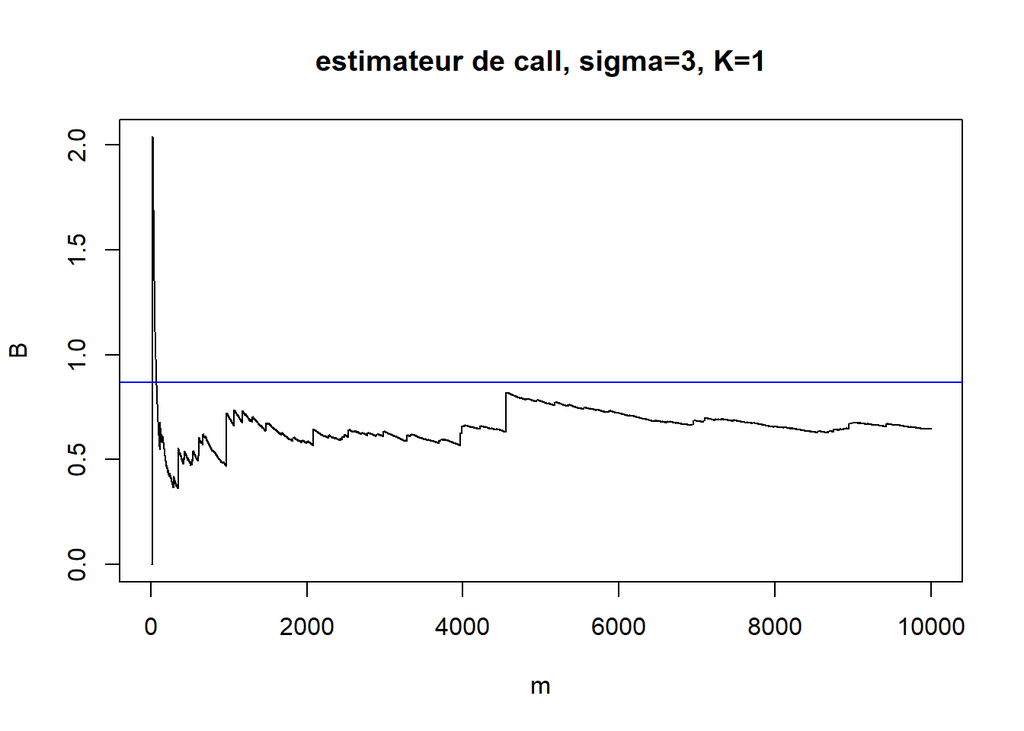

```r
#test2
A<-rcallput(10000,3,1)
B<-cumsum(A[,1])/m # Ym barre
C<-cumsum(A[,2])/m # Zm barre
call_niveau<-call(3,1)
put_niveau<-put(3,1)

plot(m,B,type='l',main="estimateur de call, sigma=3, K=1")
abline(call_niveau,0,col='blue') # on converge bien vers call
```

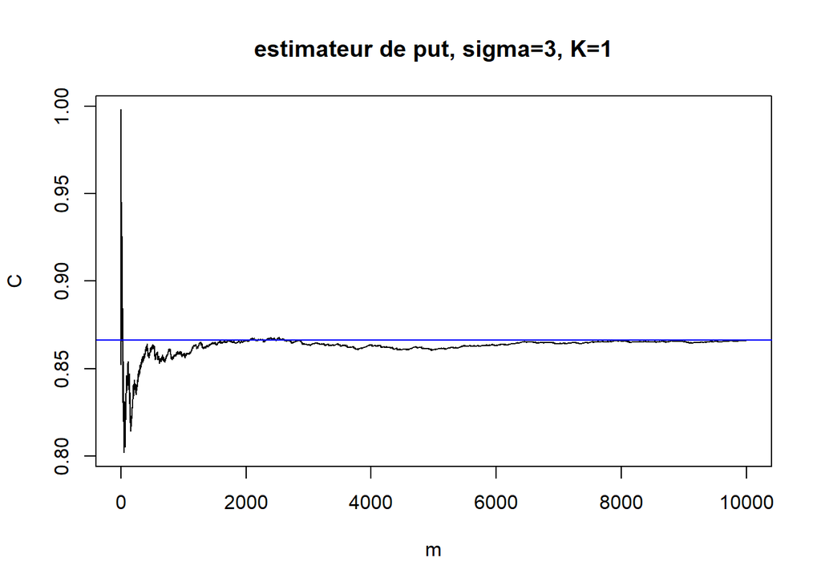

```r
plot(m,C,type='l',main="estimateur de put, sigma=3, K=1")
abline(put_niveau,0,col='blue') # on converge bien vers call
```

```r
var(B) #variance de Ym
```

```
## [1] 0.008801319
```

```r
var(C) #variance de Zm
```

```
## [1] 3.88932e-05
```

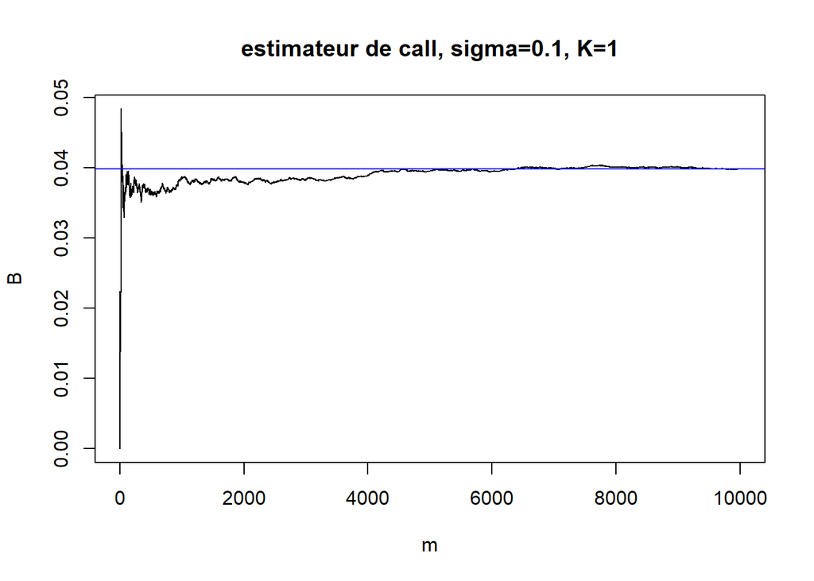

```r
#test1
A<-rcallput(10000,0.1,1)
B<-cumsum(A[,1])/m # Ym barre
C<-cumsum(A[,2])/m # Zm barre
call_niveau<-call(0.1,1)
put_niveau<-put(0.1,1)

plot(m,B,type='l',main="estimateur de call, sigma=0.1, K=1")
abline(call_niveau,0,col='blue') # on converge bien vers call
```

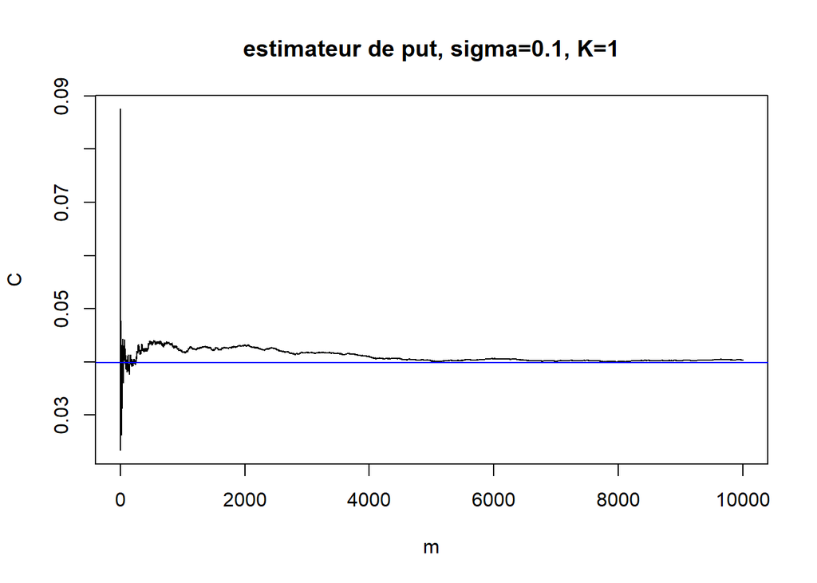

```r
plot(m,C,type='l',main="estimateur de put, sigma=0.1, K=1")
abline(put_niveau,0,col='blue') # on converge bien vers call
```

```r
var(B) #variance de Ym
```

```
## [1] 2.096543e-06
```

```r
var(C) #variance de Zm
```

```
## [1] 1.604615e-06
```

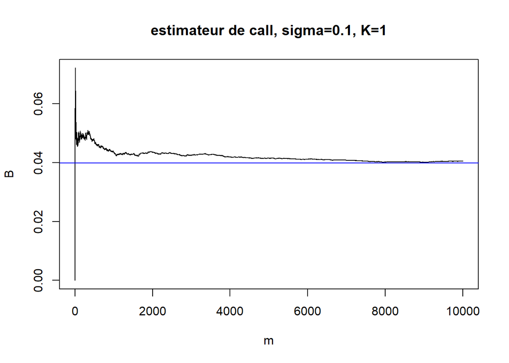

```r
#test2
A<-rcallput(10000,0.1,1)
B<-cumsum(A[,1])/m # Ym barre
C<-cumsum(A[,2])/m # Zm barre
call_niveau<-call(0.1,1)
put_niveau<-put(0.1,1)

plot(m,B,type='l',main="estimateur de call, sigma=0.1, K=1")
abline(call_niveau,0,col='blue') # on converge bien vers call
```

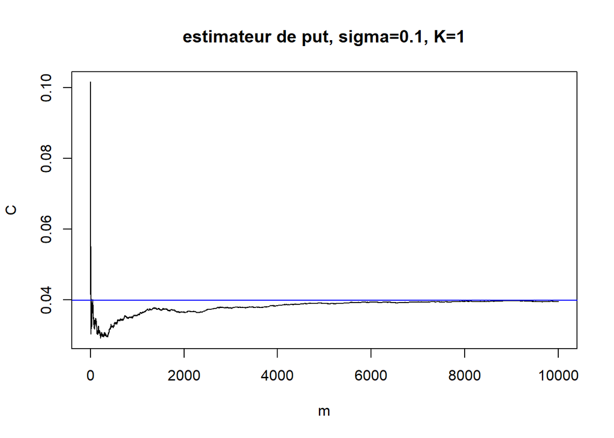

```r
plot(m,C,type='l',main="estimateur de put, sigma=0.1, K=1")
abline(put_niveau,0,col='blue') # on converge bien vers call
```

```r
var(B) #variance de Ym
```

```
## [1] 5.136028e-06
```

```r
var(C) #variance de Zm
```

```
## [1] 4.547919e-06
```

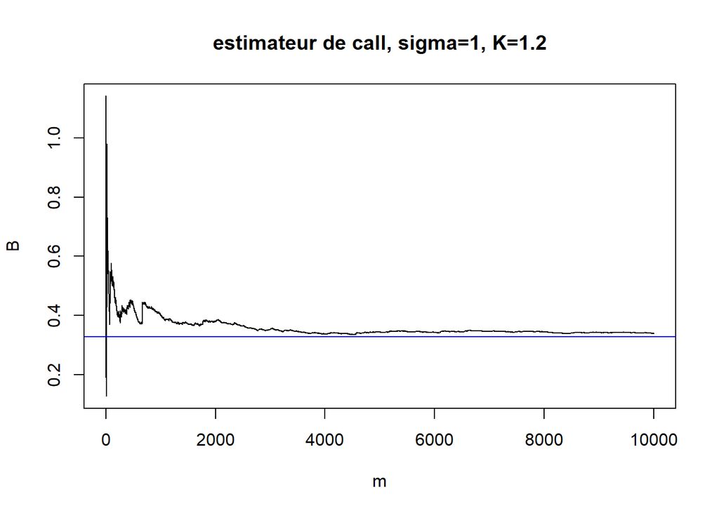

```r
#test1
A<-rcallput(10000,1,1.2)
B<-cumsum(A[,1])/m # Ym barre
C<-cumsum(A[,2])/m # Zm barre
call_niveau<-call(1,1.2)
put_niveau<-put(1,1.2)

plot(m,B,type='l',main="estimateur de call, sigma=1, K=1.2")
abline(call_niveau,0,col='blue') # on converge bien vers call
```

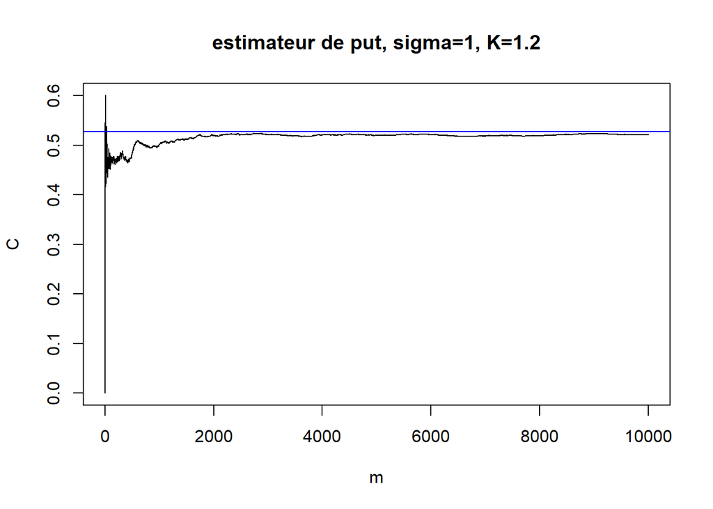

```r
plot(m,C,type='l',main="estimateur de put, sigma=1, K=1.2")
abline(put_niveau,0,col='blue') # on converge bien vers call
```

```r
var(B) #variance de Ym
```

```
## [1] 0.001244787
```

```r
var(C) #variance de Zm
```

```
## [1] 0.0001675351
```

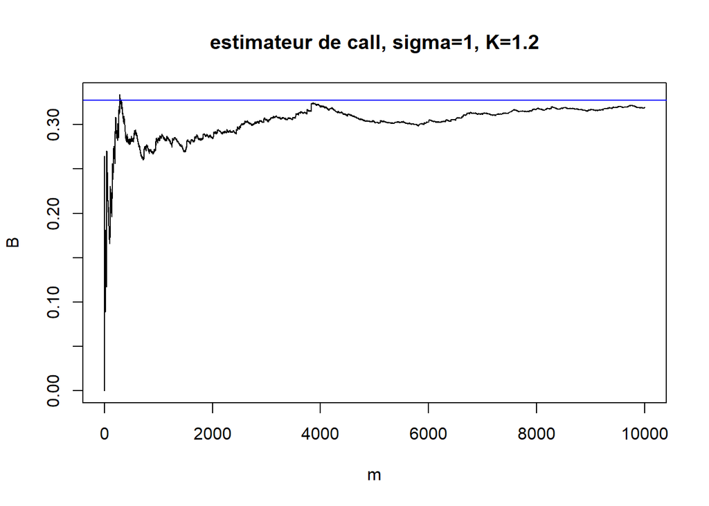

```r
#test2
A<-rcallput(10000,1,1.2)
B<-cumsum(A[,1])/m # Ym barre
C<-cumsum(A[,2])/m # Zm barre
call_niveau<-call(1,1.2)
put_niveau<-put(1,1.2)

plot(m,B,type='l',main="estimateur de call, sigma=1, K=1.2")
abline(call_niveau,0,col='blue') # on converge bien vers call
```

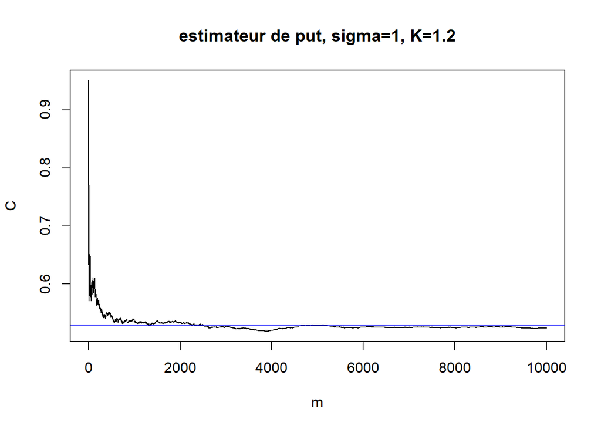

```r
plot(m,C,type='l',main="estimateur de put, sigma=1, K=1.2")
abline(put_niveau,0,col='blue') # on converge bien vers call
```

```r
var(B) #variance de Ym
```

```
## [1] 0.0004266513
```

```r
var(C) #variance de Zm
```

```
## [1] 0.0001659108
```

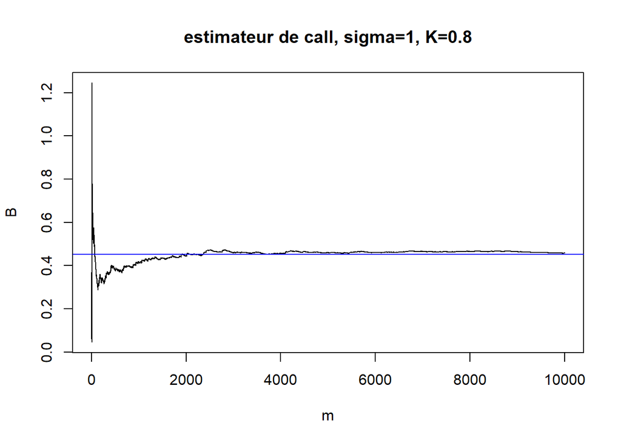

```r
#test1
A<-rcallput(10000,1,0.8)
B<-cumsum(A[,1])/m # Ym barre
C<-cumsum(A[,2])/m # Zm barre
call_niveau<-call(1,0.8)
put_niveau<-put(1,0.8)

plot(m,B,type='l',main="estimateur de call, sigma=1, K=0.8")
abline(call_niveau,0,col='blue') # on converge bien vers call
```